# Case 31: Summary of Data Analysis

- Show All Code
- Hide All Code
- View Source

H1 and H2 - Employees Federal Credit Union

Author

Jake Evans

Published

November 18, 2026

**Show R code**

```r
library(tidyverse)
library(haven)
library(car)
library(knitr)

theme_set(theme_minimal(base_size = 13))

# Cleaned data provided for Case 31 (Case 31 Data_efcu_4.sav)
aware_lab <- c("Unaware", "Aware but Have Not Used", "Aware and Have Used")

case31 <- read_sav("Case31_Data_efcu_4.sav") |>
  zap_labels() |>
  mutate(q13r = factor(q13_r, levels = 1:3, labels = aware_lab))

fmt_p <- function(p) ifelse(p < .001, "< .001", sub("^0", "", sprintf("%.3f", p)))
```

# 1 Data and Measures

- **Data:** `Case 31 Data_efcu_4.sav` (cleaned data provided for the case), *N* = 128 members.
- **Recoded variables used:** q13r (1 = Unaware, 2 = Aware but Have Not Used, 3 = Aware and Have Used) and q8r (1 = Very Low to 5 = Very High; “No opinion” set to missing).

# 2 H1: Awareness of Regular Share Accounts and Adequacy of Financial Services

> **H1:** Members’ awareness of the regular share accounts will influence their opinions on the adequacy of financial services in meeting members’ needs.
- **Constructs and roles:** awareness of the regular share account (IV); adequacy of financial services in meeting members’ needs (DV)
- **Operationalization:** q13r (ordinal, 3 groups); q33 (interval, 1 = Strongly Disagree to 5 = Strongly Agree)
- **Statistics:** descriptive statistics, followed by a one-way ANOVA. A one-way ANOVA fits because the IV has three groups and the DV is interval; a *t*-test can compare only two groups.

## 2.1 Descriptive Statistics

**Show R code**

```r
h1_desc <- case31 |>
  group_by(Awareness = q13r) |>
  summarise(n = n(), Mean = round(mean(q33), 2), SD = round(sd(q33), 2),
            Min = min(q33), Max = max(q33)) |>
  bind_rows(case31 |>
              summarise(Awareness = "Overall", n = n(), Mean = round(mean(q33), 2),
                        SD = round(sd(q33), 2), Min = min(q33), Max = max(q33)))
kable(h1_desc)
```

Table 1: Adequacy of financial services (q33) by awareness of the regular share account (q13r)

| Awareness | n | Mean | SD | Min | Max |
| --- | --- | --- | --- | --- | --- |
| Unaware | 83 | 3.63 | 0.66 | 2 | 5 |
| Aware but Have Not Used | 32 | 3.72 | 0.63 | 3 | 5 |
| Aware and Have Used | 13 | 3.08 | 0.76 | 2 | 4 |
| Overall | 128 | 3.59 | 0.68 | 2 | 5 |

**Show R code**

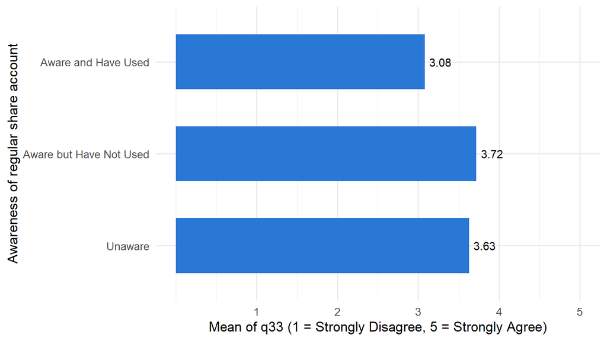

Figure 1: Mean adequacy of financial services (q33) by awareness of the regular share account

```r
h1_desc |>
  filter(Awareness != "Overall") |>
  mutate(Awareness = factor(Awareness, levels = aware_lab)) |>
  ggplot(aes(Mean, Awareness)) +
  geom_col(fill = "#2a78d6", width = 0.6) +
  geom_text(aes(label = sprintf("%.2f", Mean)), hjust = -0.2) +
  scale_x_continuous(limits = c(0, 5), breaks = 1:5) +
  labs(x = "Mean of q33 (1 = Strongly Disagree, 5 = Strongly Agree)",
       y = "Awareness of regular share account")
```

## 2.2 One-way ANOVA

- $H_0$: all group means are equal ($\mu_{Unaware} = \mu_{Aware, not used} = \mu_{Aware, used}$)
- $H_A$: at least one pair of group means is different

### 2.2.1 Normality of Residuals

**Show R code**

```r
h1_aov <- aov(q33 ~ q13r, data = case31)
h1_shapiro <- shapiro.test(residuals(h1_aov))
h1_shapiro
```

```
    Shapiro-Wilk normality test

data:  residuals(h1_aov)
W = 0.87843, p-value = 7.927e-09
```

### 2.2.2 Homogeneity of Variance

**Show R code**

```r
h1_levene <- leveneTest(q33 ~ q13r, data = case31)
h1_levene
```

```
Levene's Test for Homogeneity of Variance (center = median)
       Df F value Pr(>F)
group   2  0.0869 0.9168
      125
```

### 2.2.3 ANOVA Test

**Show R code**

```r
h1_sum <- summary(h1_aov)
h1_sum
```

```
             Df Sum Sq Mean Sq F value Pr(>F)
q13r          2   4.06  2.0307   4.631 0.0115 *
Residuals   125  54.81  0.4385
---
Signif. codes:  0 '***' 0.001 '**' 0.01 '*' 0.05 '.' 0.1 ' ' 1
```

Because the residuals are not normally distributed, the Kruskal-Wallis test (the non-parametric alternative) is run as a check.

**Show R code**

```r
h1_kw <- kruskal.test(q33 ~ q13r, data = case31)
h1_kw
```

```
    Kruskal-Wallis rank sum test

data:  q33 by q13r
Kruskal-Wallis chi-squared = 7.1098, df = 2, p-value = 0.02858
```

### 2.2.4 Post-hoc Analysis

**Show R code**

```r
# After a significant ANOVA
h1_tukey <- TukeyHSD(h1_aov)
h1_tukey
```

```
  Tukey multiple comparisons of means
    95% family-wise confidence level

Fit: aov(formula = q33 ~ q13r, data = case31)

$q13r
                                                   diff        lwr         upr
Aware but Have Not Used-Unaware              0.09224398 -0.2345927  0.41908065
Aware and Have Used-Unaware                 -0.54958295 -1.0180950 -0.08107087
Aware and Have Used-Aware but Have Not Used -0.64182692 -1.1584282 -0.12522563
                                                p adj
Aware but Have Not Used-Unaware             0.7816413
Aware and Have Used-Unaware                 0.0170339
Aware and Have Used-Aware but Have Not Used 0.0106252
```

**Show R code**

```r
# After a significant Kruskal-Wallis test: pairwise Wilcoxon tests, Bonferroni-adjusted
h1_wilcox <- pairwise.wilcox.test(case31$q33, case31$q13r, p.adjust.method = "bonferroni",
                                  exact = FALSE)
h1_wilcox
```

```
    Pairwise comparisons using Wilcoxon rank sum test with continuity correction

data:  case31$q33 and case31$q13r

                        Unaware Aware but Have Not Used
Aware but Have Not Used 1.000   -
Aware and Have Used     0.038   0.042

P value adjustment method: bonferroni
```

## 2.3 Insights about H1

**Show R code**

```r
h1_F  <- h1_sum[[1]][["F value"]][1]
h1_df <- h1_sum[[1]][["Df"]]
h1_p  <- h1_sum[[1]][["Pr(>F)"]][1]
tk    <- h1_tukey$q13r
m     <- setNames(h1_desc$Mean[1:3], aware_lab)
```

**NoteInsights about H1**

# 3 H2: Opinion on CU Loan Rates vs. Belief that CU Rates Are Lower

> **H2:** Members will not be different in their opinion on CU’s loan rate (q8r) and the degree to which they agree that CU’s loan rate is lower than competitors (q30).
- **Operationalization:** q8r, opinion about the rates charged on funds borrowed (interval, 1 = Very Low to 5 = Very High); q30, CU loan rates are lower than others (interval, 1 = Strongly Disagree to 5 = Strongly Agree)
- **Statistics:** descriptive statistics, followed by a paired-samples *t*-test. A paired test fits because the same members answered both questions, so the two scores are not independent samples.

## 3.1 Descriptive Statistics

**Show R code**

```r
h2 <- case31 |>
  select(q8r = Q8_r, q30) |>
  drop_na()

h2 |>
  pivot_longer(everything(), names_to = "Variable", values_to = "y") |>
  group_by(Variable) |>
  summarise(n = n(), Mean = round(mean(y), 2), SD = round(sd(y), 2),
            Min = min(y), Max = max(y)) |>
  mutate(Variable = c("q8r: Opinion about rates charged on funds borrowed",
                      "q30: CU loan rates lower than others")) |>
  kable()
```

Table 2: Descriptive statistics for q8r and q30 (members who answered both)

[output not shown]

**Show R code**

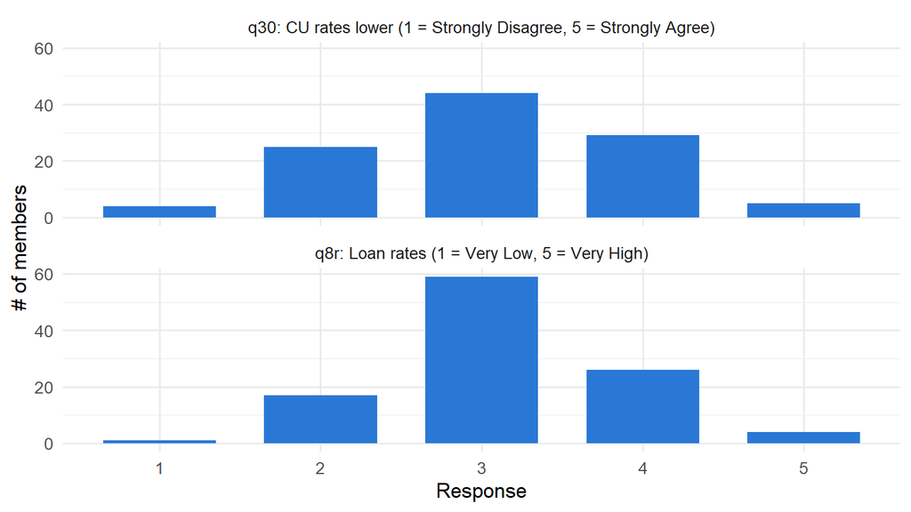

Figure 2: Response distributions for q8r and q30 (members who answered both)

```r
h2 |>
  pivot_longer(everything(), names_to = "Variable", values_to = "y") |>
  mutate(Variable = dplyr::recode(Variable,
                           q8r = "q8r: Loan rates (1 = Very Low, 5 = Very High)",
                           q30 = "q30: CU rates lower (1 = Strongly Disagree, 5 = Strongly Agree)")) |>
  count(Variable, y) |>
  ggplot(aes(factor(y), n)) +
  geom_col(fill = "#2a78d6", width = 0.7) +
  facet_wrap(~Variable, ncol = 1) +
  labs(x = "Response", y = "# of members")
```

## 3.2 Paired-Samples t-test

- $H_0: \mu_{q8r} = \mu_{q30}$ (mean difference = 0)
- $H_A: \mu_{q8r} \neq \mu_{q30}$

**Show R code**

```r
h2_t <- t.test(h2$q8r, h2$q30, paired = TRUE)
h2_t
```

```
    Paired t-test

data:  h2$q8r and h2$q30
t = 0.60088, df = 106, p-value = 0.5492
alternative hypothesis: true mean difference is not equal to 0
95 percent confidence interval:
 -0.1934139  0.3616382
sample estimates:
mean difference
     0.08411215
```

## 3.3 Insights about H2

**NoteInsights about H2**

- Members’ opinion on the CU’s loan rate (*M* = 3.14) and their agreement that the CU’s loan rate is lower than competitors’ (*M* = 3.06) are not different (*t*(106) = 0.6, *p* = .549), supporting H2 (Table 2).
- Both scores sit near the middle of their scales (Figure 2): the most common answers are that the CU’s loan rates are “Average” (55.1%) and “Uncertain” whether they are lower than competitors’ (41.1%).
- Members do not see the CU’s loan rates as an advantage, which may help explain why they borrow elsewhere.

# 4 Appendix

## 4.1 Links

- [GitHub Pages: this report](https://jakevns.github.io/IBM6500/IC-Case31-Summary-H1-H2/Evans_Jake-IC-Case31-Summary-H1-H2.html)
- [GitHub Repo: assignment folder](https://github.com/jakevns/IBM6500/tree/main/IC-Case31-Summary-H1-H2)